# Solutions for week09

Author

Jarkko Toivonen

Published

June 13, 2026

```r
library(tibble)
library(purrr)
library(dplyr)
library(stringr)
library(ggcyto)
```

# Problem 1

> Modify one of the simpler functions (SecondFunction or similar), provide your own argument names, and modify the message(), paste0 or print() functions to print a text style output. Generate a small vector of values, and iterate through your vector using one of the approaches we used.

```r
f <- function(name, level, max = 5) {
  v <- c(rep(" ", max - level), rep("*", level))
  prefix <- v |> paste(collapse = "")
  suffix <- v |> rev() |> paste(collapse = "")
  sprintf("%s %s %s", prefix, name, suffix)
}
1:3 |> map_chr(\(i) f("John", i)) %>% cat(sep = "\n")
```

```
    * John *
   ** John **
  *** John ***
```

# Problem 2

> Using the initial framework for the CellConcentration function, retrieve several other keywords that are of interest, and incorporate them into the returned data.frame row.

Read the files and create a gating set.

```r
data_path <- file.path("data") # Quarto Rendering path

fcs_files <- list.files(data_path, pattern=".fcs", full.names=TRUE)
MyCytoset <- load_cytoset_from_fcs(fcs_files, transformation=FALSE, truncate_max_range=FALSE)
MyGatingSet <- GatingSet(MyCytoset)
```

Check all the keywords.

```r
kws <- keyword(MyGatingSet[[1]])
head(kws)
```

```
$FCSversion
[1] "3.0999999"

$`$BEGINDATA`
[1] "15152"

$`$ENDDATA`
[1] "8436079"

$`$BEGINANALYSIS`
[1] "0"

$`$ENDANALYSIS`
[1] "0"

$`$BEGINSTEXT`
[1] "0"
```

```r
CellConcentration <- function(x){
    kw <- keyword(x)
    Date <- kw$`$DATE` # Day-Month-Year
    InstrumentSerial <- kw$`$CYTSN`
    Creator <- kw$CREATOR             # Added
    TotalFileEvents <- kw$`$TOT`
    Specimen <- kw$GUID
    FCSversion <- kw$FCSversion       # Added
    StartTime <- kw$`$BTIM`
    EndTime <- kw$`$ETIM`
    Volume <- kw$`$VOL`

    # Count the number of lasers
    Lasers <- names(kw) |> keep(\(x) str_detect(x, "LASER[0-9]+NAME")) %>% length()

    res <- tibble(
        Date = Date,
        InstrumentSerial = InstrumentSerial,
        Creator = Creator,
        TotalFileEvents = TotalFileEvents,
        Specimen = Specimen,
        FCSversion = FCSversion,
        StartTime = StartTime,
        EndTime = EndTime,
        Volume = Volume,
        Lasers = Lasers
    )
    res
}
CellConcentration(MyGatingSet[[1]])
```

| Date | InstrumentSerial | Creator | TotalFileEvents | Specimen | FCSversion | StartTime | EndTime | Volume | Lasers |
| --- | --- | --- | --- | --- | --- | --- | --- | --- | --- |
| 30-Jul-2025 | V0333 | SpectroFlo 3.3.0 | 34512 | CellCounts4L_AB_04-INF124-7-00_01.fcs | 3.0999999 | 13:48:10.76 | 13:48:37.88 | 30.99 | 4 |

# Problem 3

> For CellConcentration, we retrieved both start and end time. Look up information on lubridate package, convert these times to a time-style format, and from acquired volume derrive uL/min at which each .fcs file was acquired. Did this vary at all across days?

Data File Standard for Flow Cytometry, Version FCS 3.1 https://pmc.ncbi.nlm.nih.gov/articles/PMC2892967/

> Sample Volume: A standardized way to communicate the sample volume has been introduced. The value of a new optional $VOL keywords is a floating point number expressing the sample volume in nanoliters.

But based on the scale, about 30, it looks that the volume in the file could be in microlitres (uL) instead!

I will assume that the unit is microlitres.

```r
#' This function will figure out the cell concentration
#'  for a given gated population in an .fcs file
#'
#' @param x A GatingSet object (typically iterated in)
#' @param subset The gate from which to retrieve cell counts from
#' @param dilutionMultiplier Multiplies the estimated concentration
#'  to bring correct digits.
#'
CellConcentration3 <- function(x, subset, dilutionMultiplier){
    Date <- keyword(x)$`$DATE` # Day-Month-Year
    InstrumentSerial <- keyword(x)$`$CYTSN`
    TotalFileEvents <- keyword(x)$`$TOT`
    Specimen <- keyword(x)$GUID
    StartTime <- keyword(x)$`$BTIM`
    EndTime <- keyword(x)$`$ETIM`

    StartTime <- hms::as_hms(StartTime)
    EndTime <- hms::as_hms(EndTime)
    Duration <- EndTime - StartTime

    Volume <- keyword(x)$`$VOL`
    Volume <- as.numeric(Volume)    # In nanolitres or microlitres, maybe the latter

    EventsInTheGate <- gs_pop_get_data(x, subset)
    Cells <- nrow(EventsInTheGate)[[1]] # [[1]] since the output is in a list

    Concentration <- (Cells*1000)/Volume   # Apparently this converts to cells per millilitres?
    Concentration <- Concentration*dilutionMultiplier

    CellsPerSecond <- Cells / as.numeric(Duration, unit = "secs")

    Flow <- Volume / as.numeric(Duration, unit = "mins")  # microlitres per minute (uL/min)
    FlowUnit <- "uL/min"

    Data <- tibble(
        Date=Date,
        InstrumentSerial=InstrumentSerial,
        Specimen=Specimen,
        StartTime=StartTime,
        EndTime=EndTime,
        Duration = Duration,
        Volume=Volume,    # In nanolitres or microlitres, maybe the latter
        Cells=Cells,
        Concentration=Concentration,
        CellsPerSecond = CellsPerSecond,
        Flow = Flow,
        FlowUnit = FlowUnit
        )

    return(Data)
}
```

The flow is of the diluted liquid.

Transform the data.

```r
MainDetectorsOnly <- c("V3-A", "B4-A", "R1-A")

Biexponential <- flowjo_biexp_trans(channelRange=4096, maxValue=262144,
     pos=4.5, neg=2, widthBasis=-500)
MyBiexTransform <- transformerList(MainDetectorsOnly, Biexponential)
transform(MyGatingSet, MyBiexTransform)
```

```
A GatingSet with 9 samples
```

Gate it.

```r
GatingTable <- tibble::tribble(
  ~filterId,    ~dims,                          ~subset,
  "CD45",       list("B4-A", "SSC-A"),            "root",
  "CD19",       list("V3-A", "SSC-A"),            "CD45",
  "CD14",       list("R1-A", "SSC-A"),            "CD45",
  "TandNKcells",  list("V3-A", "SSC-A"),            "CD45",
)
GatingTable
```

| filterId | dims | subset |
| --- | --- | --- |
| CD45 | B4-A, SSC-A | root |
| CD19 | V3-A, SSC-A | CD45 |
| CD14 | R1-A, SSC-A | CD45 |
| TandNKcells | V3-A, SSC-A | CD45 |

```r
filename <- file.path(data_path, "gated.gs")
if (! file.exists(filename)) {
    flowGate::gs_apply_gating_strategy(MyGatingSet, gating_strategy = GatingTable)
    save_gs(MyGatingSet, filename)
} else {
    MyGatingSet <- load_gs(filename)
}
```

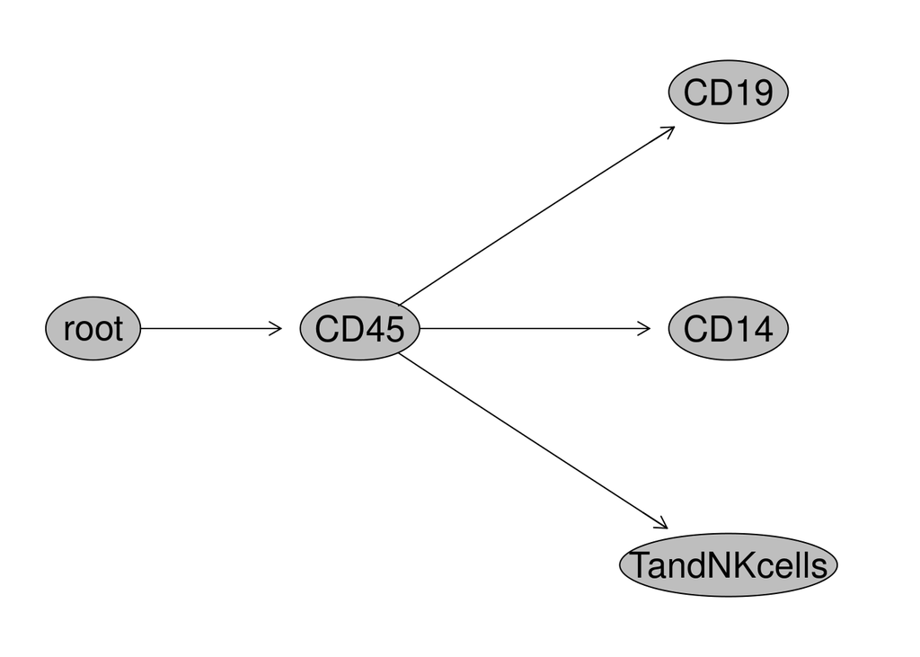

```r
plot(MyGatingSet)
```

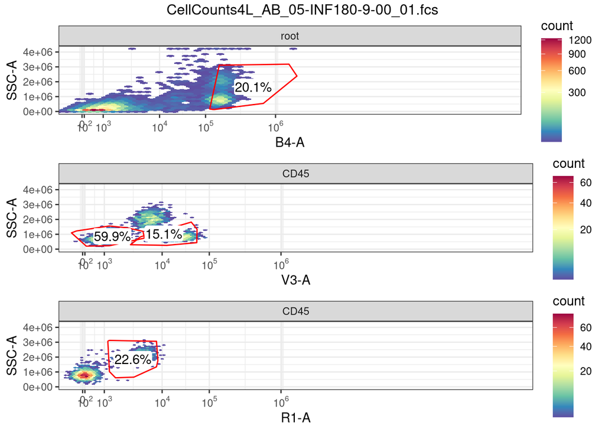

```r
ggcyto::autoplot(MyGatingSet[[6]]) + theme_bw()
```

```r
population <- "root"
get_results_for_population <- function(gating_set, population) {
    df <- gating_set |>
        map(\(x) CellConcentration3(x, subset=population, dilutionMultiplier=100)) |>
        bind_rows()
    df
}
df <- get_results_for_population(MyGatingSet, population)
df
```

| Date | InstrumentSerial | Specimen | StartTime | EndTime | Duration | Volume | Cells | Concentration | CellsPerSecond | Flow | FlowUnit |
| --- | --- | --- | --- | --- | --- | --- | --- | --- | --- | --- | --- |
| 30-Jul-2025 | V0333 | CellCounts4L_AB_04-INF124-7-00_01.fcs | 13:48:10.76 | 13:48:37.88 | 27.12 secs | 30.99 | 34512 | 111364956 | 1272.5664 | 68.56195 | uL/min |
| 30-Jul-2025 | V0333 | CellCounts4L_AB_04-INF149-4-00_01.fcs | 13:33:43.49 | 13:34:09.95 | 26.46 secs | 30.93 | 19656 | 63549952 | 742.8571 | 70.13605 | uL/min |
| 30-Jul-2025 | V0333 | CellCounts4L_AB_04-INF169-6-00_01.fcs | 13:40:42.92 | 13:41:10.01 | 27.09 secs | 30.81 | 23328 | 75715677 | 861.1296 | 68.23920 | uL/min |
| 04-Aug-2025 | V0333 | CellCounts4L_AB_05-INF019-0-00_01.fcs | 13:41:23.34 | 13:41:50.51 | 27.17 secs | 30.47 | 24976 | 81969150 | 919.2492 | 67.28745 | uL/min |
| 04-Aug-2025 | V0333 | CellCounts4L_AB_05-INF032-5-00_01.fcs | 13:35:13.99 | 13:35:41.15 | 27.16 secs | 30.64 | 12816 | 41827676 | 471.8704 | 67.68778 | uL/min |
| 04-Aug-2025 | V0333 | CellCounts4L_AB_05-INF180-9-00_01.fcs | 13:48:19.41 | 13:48:46.83 | 27.42 secs | 30.73 | 12088 | 39336154 | 440.8461 | 67.24289 | uL/min |
| 06-Aug-2025 | V0333 | CellCounts4L_AB_06-INF155-1-00_01.fcs | 13:45:36.08 | 13:46:03.30 | 27.22 secs | 30.94 | 36992 | 119560440 | 1359.0007 | 68.19985 | uL/min |
| 06-Aug-2025 | V0333 | CellCounts4L_AB_06-INF158-4-00_01.fcs | 13:39:27.95 | 13:39:54.12 | 26.17 secs | 30.03 | 23952 | 79760240 | 915.2465 | 68.84983 | uL/min |
| 06-Aug-2025 | V0333 | CellCounts4L_AB_06-INF159-5-00_01.fcs | 13:52:09.56 | 13:52:36.75 | 27.19 secs | 30.93 | 8792 | 28425477 | 323.3542 | 68.25303 | uL/min |

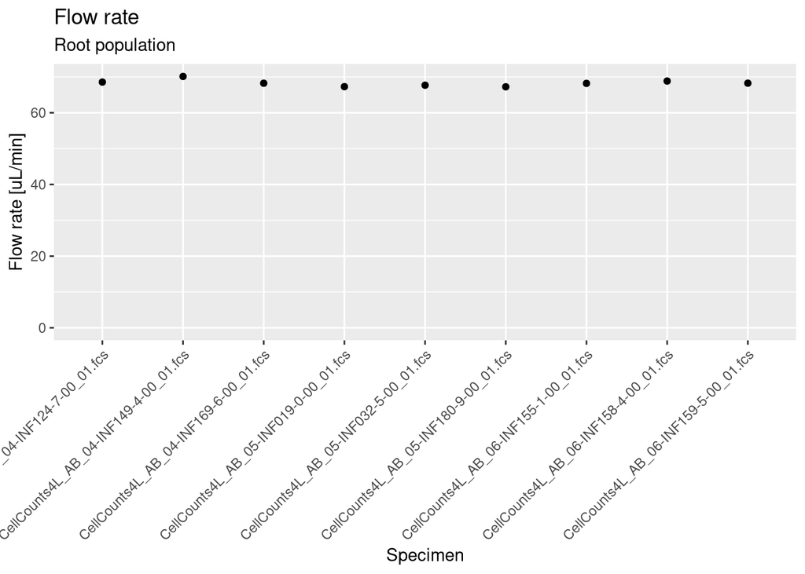

```r
df %>%
    ggplot(aes(Specimen, Flow)) +
    geom_point() +
    lims(y = c(0, NA)) +
    labs(x = "Specimen", y = "Flow rate [uL/min]",
    title = "Flow rate", subtitle = "Root population") +
    theme(axis.text.x = element_text(angle = 45, hjust = 1))
```

The flow rate is almost constant across specimen so the day doesn’t affect it.

Let’s also check the population-wise cell rate, so that the creation of gates is not totally wasted.

```r
populations <- gs_get_pop_paths(MyGatingSet)
populations
```

```
[1] "root"              "/CD45"             "/CD45/CD19"
[4] "/CD45/CD14"        "/CD45/TandNKcells"
```

Get results for all populations.

```r
dfs <- populations |>
    set_names() |>     # Results in a named list, where the name is the same as the value
    map(\(population) get_results_for_population(MyGatingSet, population))
all <- bind_rows(dfs, .id = "population")   # The name of the list element goes to the population column
all |> head()
```

| population | Date | InstrumentSerial | Specimen | StartTime | EndTime | Duration | Volume | Cells | Concentration | CellsPerSecond | Flow | FlowUnit |
| --- | --- | --- | --- | --- | --- | --- | --- | --- | --- | --- | --- | --- |
| root | 30-Jul-2025 | V0333 | CellCounts4L_AB_04-INF124-7-00_01.fcs | 13:48:10.76 | 13:48:37.88 | 27.12 secs | 30.99 | 34512 | 111364956 | 1272.5664 | 68.56195 | uL/min |
| root | 30-Jul-2025 | V0333 | CellCounts4L_AB_04-INF149-4-00_01.fcs | 13:33:43.49 | 13:34:09.95 | 26.46 secs | 30.93 | 19656 | 63549952 | 742.8571 | 70.13605 | uL/min |
| root | 30-Jul-2025 | V0333 | CellCounts4L_AB_04-INF169-6-00_01.fcs | 13:40:42.92 | 13:41:10.01 | 27.09 secs | 30.81 | 23328 | 75715677 | 861.1296 | 68.23920 | uL/min |
| root | 04-Aug-2025 | V0333 | CellCounts4L_AB_05-INF019-0-00_01.fcs | 13:41:23.34 | 13:41:50.51 | 27.17 secs | 30.47 | 24976 | 81969150 | 919.2492 | 67.28745 | uL/min |
| root | 04-Aug-2025 | V0333 | CellCounts4L_AB_05-INF032-5-00_01.fcs | 13:35:13.99 | 13:35:41.15 | 27.16 secs | 30.64 | 12816 | 41827676 | 471.8704 | 67.68778 | uL/min |
| root | 04-Aug-2025 | V0333 | CellCounts4L_AB_05-INF180-9-00_01.fcs | 13:48:19.41 | 13:48:46.83 | 27.42 secs | 30.73 | 12088 | 39336154 | 440.8461 | 67.24289 | uL/min |

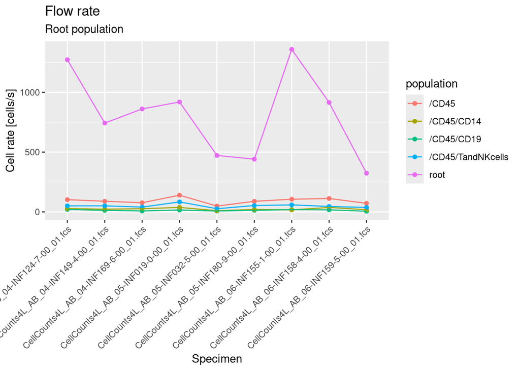

```r
all %>%
    ggplot(aes(Specimen, CellsPerSecond, color = population, group = population)) +
    geom_point() +
    geom_line() +
    lims(y = c(0, NA)) +
    labs(x = "Specimen", y = "Cell rate [cells/s]",
    title = "Flow rate", subtitle = "Root population") +
    theme(axis.text.x = element_text(angle = 45, hjust = 1))
```

Hmm, the amount of rubbish seems to vary.